# Can the internet tell me when to buy and sell stocks?

Matt Moocarme

June 2, 2016

### Thesis

Stock market prices flutuate in a way that is notoriously difficult to predict. Here I will attempt to use data accululated through the internet to attempt to predict when there will be large flutuations in stock market prices that will trigger a buy or sell action.

My hypothesis is that many fluctuations in the stock market prices may be predicted by analysing news reports, twitter feeds, etc. For example the stock prices of Apple climb at the release of a new product, around the time of the release there is likely to be many different news reports and articles posted amongst the web, as well as many consumers tweeting their excitement for the upcoming product.

By incorporating this information perhaps I can better predict large flutuations in stock market prices and generate higher returns on investments.

First I will begin by loading in the data and tidying it up. My goal is to have each column a separate variable, and each row a separate observation. I will load in the data using the quantmod package. Data tidying will be done using dplyr and tidyr. Additional help will come from the zoo, xts, and TTR libraries since the historical stock data comes in xts form due to its ease with working with time-series data.

```r
library(zoo)
library(TTR)
library(xts)
library(quantmod)
library(dplyr)
library(tidyr)
```

### Grabbing stock indices

Here I add in the stock symbols that I want, the function getSymbols generates an xts file for each stock symbol with the same name.

```r
# Choose stock company
Nasdaq100_Symbols <- c('AAPL', 'AMZN')
stocks <- getSymbols(Nasdaq100_Symbols)
```

Since the stock data is separate for each stock I will combine them in a matrix named df, and also combine the column names in a separate list as this will be useful in understanding the data

```r
cols = list()
df <- matrix(data = NA, ncol = 6*length(stocks), nrow = dim(get(stocks[1]))[1])
for(i in 1:length(stocks)){
  in1 <- 6*(i-1)+1
  in2 <- 6*i
  df[,in1:in2] <- get(stocks[i])
  cols <- c(cols, colnames(get(stocks[i])))
}
colnames(df) <- cols
```

Next row names are added and a separate column for the date is added, labelled, and the matrix is converted to a data frame

```r
rownames(df)<- as.character.Date(index(get(stocks[1])))
df.dates <- as.data.frame(cbind(as.character.Date(index(get(stocks[1]))), df))
colnames(df.dates)[1] <- 'Date'
head(df.dates)
```

```
##                  Date AAPL.Open AAPL.High  AAPL.Low AAPL.Close AAPL.Volume
## 2007-01-03 2007-01-03 86.289999 86.579999 81.899999  83.800002   309579900
## 2007-01-04 2007-01-04 84.050001 85.949998 83.820003  85.659998   211815100
## 2007-01-05 2007-01-05     85.77 86.199997 84.400002  85.049997   208685400
## 2007-01-08 2007-01-08 85.959998 86.529998 85.280003      85.47   199276700
## 2007-01-09 2007-01-09 86.450003 92.979999     85.15  92.570003   837324600
## 2007-01-10 2007-01-10 94.749999 97.800002 93.450003  96.999997   738220000
##            AAPL.Adjusted AMZN.Open AMZN.High  AMZN.Low AMZN.Close
## 2007-01-03      11.01952     38.68 39.060001 38.049999  38.700001
## 2007-01-04     11.264106     38.59 39.139999 38.259998  38.900002
## 2007-01-05     11.183892 38.720001 38.790001 37.599998  38.369999
## 2007-01-08     11.239121 38.220001 38.310001 37.169998       37.5
## 2007-01-09     12.172756 37.599998 38.060001     37.34  37.779999
## 2007-01-10     12.755291 37.490002 37.700001     37.07  37.150002
##            AMZN.Volume AMZN.Adjusted
## 2007-01-03    12405100     38.700001
## 2007-01-04     6318400     38.900002
## 2007-01-05     6619700     38.369999
## 2007-01-08     6783000          37.5
## 2007-01-09     5703000     37.779999
## 2007-01-10     6527500     37.150002
```

Now we will tidy the data using dplyr and tidyr to only include the data we are interested in. Here we will just take the adjusted values since they take into account stock splits, dividends etc which may skew prices.

```r
tidy_stocks <- as.data.frame(df.dates) %>%
  select(Date, contains('Adjusted')) %>%
  gather(Index, Price, -Date)
head(tidy_stocks)
```

```
##         Date         Index     Price
## 1 2007-01-03 AAPL.Adjusted  11.01952
## 2 2007-01-04 AAPL.Adjusted 11.264106
## 3 2007-01-05 AAPL.Adjusted 11.183892
## 4 2007-01-08 AAPL.Adjusted 11.239121
## 5 2007-01-09 AAPL.Adjusted 12.172756
## 6 2007-01-10 AAPL.Adjusted 12.755291
```

Calculating the returns on prices will be the next thing we will do. The simple daily return, $R_s$, is calculated with the relation $R_s = \frac{P_j-P_{j-1}}{P_{j-1}}$, where $P_{j}$ is the price at day $j$, and $P_{j-1}$ is the price the previous day. The log return, $R_{cc}$, is another useful relation that assumes the difference in price is calculated via continuously compounding, $R_{cc}$ is calculated using the relation $R_{cc} = \log(P_{j})-\log(P_{j-1})$.

We can add this to the data frame using the mutate function.

```r
stock_returns <- tidy_stocks %>%
  mutate(Simple.return = ifelse(lag(Index)==Index,(as.numeric(Price)-as.numeric(lag(Price)))/(as.numeric(lag(Price))),0)) %>%
  mutate(Log.return = ifelse(lag(Index)==Index,(log(as.numeric(Price))-log(as.numeric(lag(Price)))),0))
head(stock_returns)
```

```
##         Date         Index     Price Simple.return   Log.return
## 1 2007-01-03 AAPL.Adjusted  11.01952            NA           NA
## 2 2007-01-04 AAPL.Adjusted 11.264106   0.022195704  0.021952964
## 3 2007-01-05 AAPL.Adjusted 11.183892  -0.007121204 -0.007146681
## 4 2007-01-08 AAPL.Adjusted 11.239121   0.004938263  0.004926110
## 5 2007-01-09 AAPL.Adjusted 12.172756   0.083070108  0.079799701
## 6 2007-01-10 AAPL.Adjusted 12.755291   0.047855638  0.046745826
```

### Plotting the stock prices and the returns

For exploratory data analyses it is useful to plot various things to get a feel for the data. Here we will just look at apple.

Using ggplot we can plot the price as a function of time, as well all the daily log return, and a histogram of the daily log return.

```r
library(ggplot2)
aapl_returns <- stock_returns %>% filter(grepl('AAPL',Index)) %>% select(-Index)
head(aapl_returns)
```

```
##         Date     Price Simple.return   Log.return
## 1 2007-01-03  11.01952            NA           NA
## 2 2007-01-04 11.264106   0.022195704  0.021952964
## 3 2007-01-05 11.183892  -0.007121204 -0.007146681
## 4 2007-01-08 11.239121   0.004938263  0.004926110
## 5 2007-01-09 12.172756   0.083070108  0.079799701
## 6 2007-01-10 12.755291   0.047855638  0.046745826
```

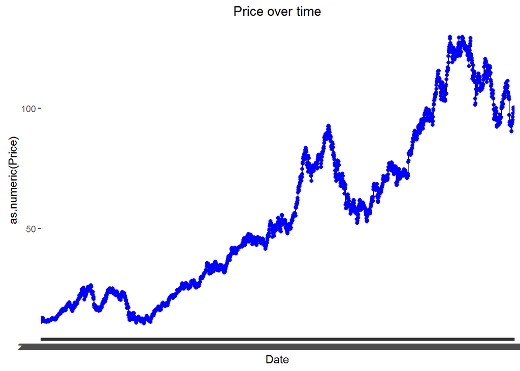

```r
plot1 <- ggplot(data = aapl_returns, aes(x = Date, y = as.numeric(Price), group = 1))+geom_line()+ geom_point(color="blue")
plot1 + ggtitle('Price over time')
```

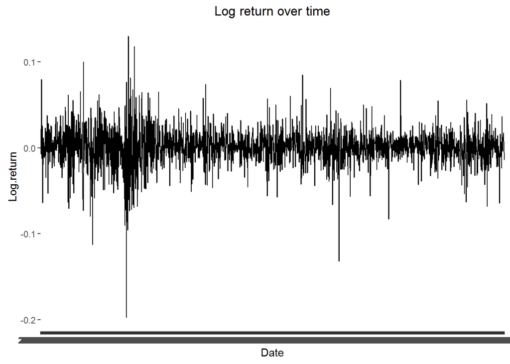

```r
plot2 <- ggplot(data = aapl_returns, aes(x = Date, y = Log.return, group = 1)) + geom_line()
plot2 + ggtitle('Log return over time')
```

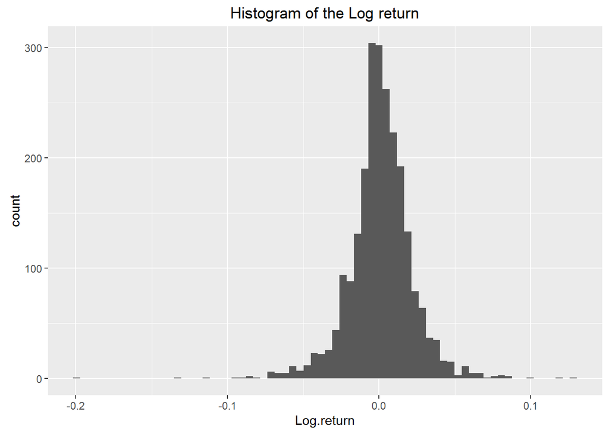

```r
plot3 <- ggplot(data = aapl_returns, aes(Log.return)) + geom_histogram(bins = 70)
plot3 + ggtitle('Histogram of the Log return')
```

```r
meanDist.daily <- mean(na.omit(aapl_returns$Log.return))
meanDist.yearly <- meanDist.daily * 252
meanDist.daily
```

```
## [1] 0.0009244331
```

```r
meanDist.yearly
```

```
## [1] 0.2329572
```

On average over the course of one day you are likely to increase the value of your stock by 0.0924% and over the year it would be 23.2957% since there are 252 trading days in a year.